# Homework 5

Dylan Maddux

2024-11-01

### Exercise 5.16

**Suppose a researcher wants to learn about a possible relationship between the main ingredient in dog food (salmon, chicken, beef) and the amount of energy that dogs have. The researcher obtains 45 Border Collies and randomly assigns each dog to one of the three diets. She then measures the average amount of time each dog sleeps per 24 hours for the next week as an indication of the amount of energy each dog has.**

**A.** Identify the explanatory and response variables in this study.

Explanatory variable: type of dog food

Response variable: sleep time

**B.** Is this an observational study or a randomized experiment? Explain how you know.

This is a randomized experiment because the dogs are being randomly assigned to one of the three diets, and the explanatory variable is being manipulated by the researcher.

**C.** Even though the subjects in this study were not randomly selected from a population, it’s still appropriate to conduct an analysis of variance. Explain why.

The subjects were not randomly selected but were randomly assigned to one of the three conditions, making inferences of differences between groups appropriate.

### Exercise 5.18

**Refer to previous exercise.**

**A.** What are the units in this experiment?

The 45 Border Collies

**B.** What are the treatments?

The three diets (salmon, chicken, and beef)

**C.** What would the researcher have to do to ensure that this experiment is balanced?

The groups need to be of equal number, meaning 15 Border Collies in each treatment group (each diet).

### Exercise 5.38

**An experiment was conducted to compare three different methods of repairing a meniscus (cartilage in the knee). Eighteen lightly embalmed cadaveric specimens were used, with each being randomly assigned to one of the three treatments: vertical suture, meniscus arrow, FasT-Fix. Each knee was evaluated on three different response variables: load at failure, stiffness, and displacement. Here we will concentrate on the stiffness response variable.**

```r
library(Stat2Data)
data("Meniscus")
```

**A.** Give the hypotheses that would be tested in an ANOVA procedure for this dataset.

$\H_{0}$: $\mu_{1}$ = $\mu_{2}$ = $\mu_{3}$

$\H_{A}$: At least one $\mu_{i}$ is not equal

**B.** Show that the conditions for ANOVA are met for these data.

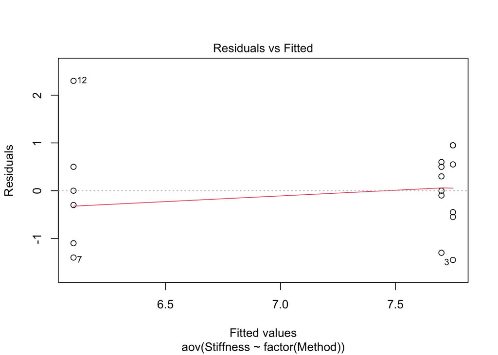

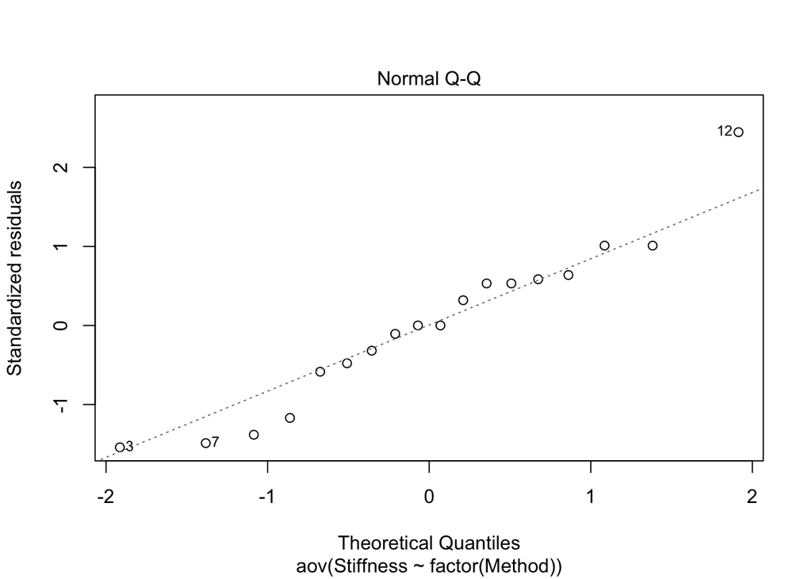

```r
c1 <- aov(Stiffness~factor(Method), Meniscus)
plot(c1, 1:2)
```

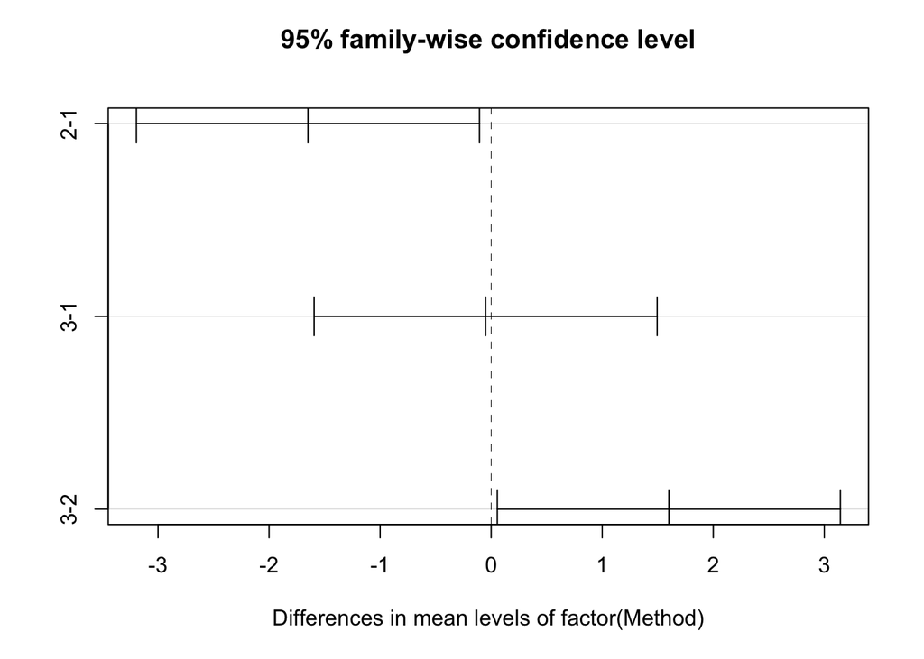

```r
plot(TukeyHSD(c1))
```

The residuals vs fitted values plot roughly displays constant variance and a near zero mean inference line, the Q-Q plot does adhere to the theoretical normal line, and the Tukey plot displays significant differences in the mean levels of the groups.

**C.** Conduct an ANOVA. Report the ANOVA table and interpret the results. Do the data provide strong evidence that the mean value of stiffness differs based on the type of meniscus repair? Explain.

```r
anova(c1)
```

```
## Analysis of Variance Table
##
## Response: Stiffness
##                Df Sum Sq Mean Sq F value  Pr(>F)
## factor(Method)  2 10.570   5.285  4.9811 0.02193 *
## Residuals      15 15.915   1.061
## ---
## Signif. codes:  0 '***' 0.001 '**' 0.01 '*' 0.05 '.' 0.1 ' ' 1
```

Yes, the data provides strong evidence that the mean value of stiffness differs based on the type of meniscus repair, since the p-value for this test output is 0.02193.

### Exercise 5.46

**We discovered that there was a significant difference between the treatments with respect to the response variable stiffness. For this variable, larger values are better (less stiffness to the specimen). The researchers were comparing a potential new treatment (FasT-Fix) to two commonly used treatments (vertical suture and meniscus 19 arrow). Use Fisher’s LSD to determine which differences exist between the treatments and discuss the ramifications of your conclusions for doctors.**

```r
library(agricolae)
print(LSD.test(c1, "factor(Method)"))
```

```
## $statistics
##   MSerror Df     Mean       CV t.value     LSD
##     1.061 15 7.183333 14.33942 2.13145 1.26757
##
## $parameters
##         test p.ajusted         name.t ntr alpha
##   Fisher-LSD      none factor(Method)   3  0.05
##
## $means
##   Stiffness       std r        se      LCL      UCL Min Max   Q25  Q50   Q75
## 1      7.75 0.9710819 6 0.4205156 6.853692 8.646308 6.3 8.7 7.225 7.80 8.600
## 2      6.10 1.3266499 6 0.4205156 5.203692 6.996308 4.7 8.4 5.200 5.95 6.475
## 3      7.70 0.6928203 6 0.4205156 6.803692 8.596308 6.4 8.3 7.625 7.85 8.150
##
## $comparison
## NULL
##
## $groups
##   Stiffness groups
## 1      7.75      a
## 3      7.70      a
## 2      6.10      b
##
## attr(,"class")
## [1] "group"
```

From the output and confidence intervals, Group 2 differs most significantly from the other 2 treatments, meaning that Fast-Fix is similarly adept at preventing stiffness as the vertical suture method, while both methods are better than the meniscus 19 arrow method. We can conclude this because the meniscus 19 arrow method has the lowest mean stiffness score out of the 3 groups, with lower values meaning more stiffness. Therefore, we would recommend to doctors to use the Fast-Fix and vertical suture methods, and avoid the meniscus 19 arrow method.

### Exercise 5.58

**A researcher wanted to know if the mean salaries of men and women are different. She chose a stratified random sample of 280 people from the 2000 U.S. Census consisting of men and women from New York State, Oregon, Arizona, and Iowa.**

**A.** Is a person’s sex significant in predicting their salary? Explain your conclusions.

**B.** What R^2 value does the ANOVA model have? Is this good? Explain.

**C.** The researcher did not look at residual plots. What conclusions do you reach about the ANOVA after examining these plots? Explain.